# Selecting the winner Model

Abdlmutaleb Boshanna

## 1. Download the Titanic data

```r
library(e1071)
library(MASS)
library(lattice)
library(PASWR)
data(titanic3)
str(titanic3)
```

```
## 'data.frame':    1309 obs. of  14 variables:
##  $ pclass   : Factor w/ 3 levels "1st","2nd","3rd": 1 1 1 1 1 1 1 1 1 1 ...
##  $ survived : int  1 1 0 0 0 1 1 0 1 0 ...
##  $ name     : Factor w/ 1307 levels "Abbing, Mr. Anthony",..: 22 24 25 26 27 31 46 47 51 55 ...
##  $ sex      : Factor w/ 2 levels "female","male": 1 2 1 2 1 2 1 2 1 2 ...
##  $ age      : num  29 0.917 2 30 25 ...
##  $ sibsp    : int  0 1 1 1 1 0 1 0 2 0 ...
##  $ parch    : int  0 2 2 2 2 0 0 0 0 0 ...
##  $ ticket   : Factor w/ 929 levels "110152","110413",..: 188 50 50 50 50 125 93 16 77 826 ...
##  $ fare     : num  211 152 152 152 152 ...
##  $ cabin    : Factor w/ 187 levels "","A10","A11",..: 45 81 81 81 81 151 147 17 63 1 ...
##  $ embarked : Factor w/ 4 levels "","Cherbourg",..: 4 4 4 4 4 4 4 4 4 2 ...
##  $ boat     : Factor w/ 28 levels "","1","10","11",..: 13 4 1 1 1 14 3 1 28 1 ...
##  $ body     : int  NA NA NA 135 NA NA NA NA NA 22 ...
##  $ home.dest: Factor w/ 369 levels "","?Havana, Cuba",..: 309 231 231 231 231 237 163 25 23 229 ...
```

## 2. **Non- parametric models**: CART vs. Bagging vs. RF vs. Boosting vs KNN in classification with Titanic dataset.

```r
a <- c("survived","sex","age","pclass","sibsp","parch")
df <- titanic3[, a]
```

```r
library(gplots)
library(PASWR)
library(ROCR)
library(rpart)
library(randomForest)
library(gbm)
df <- df[complete.cases(df),]
df$d <- as.factor(df$survived)

n <- 200
B <- 1000
AUC1 <- c()
AUC2 <- c()
AUC3 <- c()
AUC4 <- c()

for (i in 1:n) {
  ind <- sample(nrow(df), nrow(df), replace = TRUE)
  train <- df[ind, ]
  test <- df[-ind, ]

  p = ncol(train)-2 #deleting survived and d columns. I need only 5 features.

  model1 <- rpart(survived~., data=train[,-7], method = "class")
  model2 <- randomForest(d~., ntree = B, mtry = p, data = train[, -1]) #Bagged
  model3 <- randomForest(d~., ntree = B, data = train[, -1]) # RF
  model4 <- gbm(survived~., data=train[,-7], n.trees = B, distribution = "bernoulli") # Boosting

  phat1 <- predict(model1, test[,-7], type = "prob")
  phat2 <- predict(model2, test[,-1], type = "prob")
  phat3 <- predict(model3, test[,-1], type = "prob")
  phat4 <- predict(model4, n.trees = B, test[,-7], type = "response")

  #AUC1
  pred_rocr1 <- prediction(phat1[,2], test$survived)
  auc_ROCR1 <- performance(pred_rocr1, measure = "auc")
  AUC1[i] <- auc_ROCR1@y.values[[1]]

  #AUC2
  pred_rocr2 <- prediction(phat2[,2], test$d)
  auc_ROCR2 <- performance(pred_rocr2, measure = "auc")
  AUC2[i] <- auc_ROCR2@y.values[[1]]

  #AUC3
  pred_rocr3 <- prediction(phat3[,2], test$d)
  auc_ROCR3 <- performance(pred_rocr3, measure = "auc")
  AUC3[i] <- auc_ROCR3@y.values[[1]]

  #AUC4
  pred_rocr4 <- prediction(phat4, test$survived)
  auc_ROCR4 <- performance(pred_rocr4, measure = "auc")
  AUC4[i] <- auc_ROCR4@y.values[[1]]
}

mean(AUC1)
```

```
## [1] 0.8136204
```

```r
mean(AUC2)
```

```
## [1] 0.8112935
```

```r
mean(AUC3)
```

```
## [1] 0.8411876
```

```r
mean(AUC4)
```

```
## [1] 0.8349397
```

```r
sqrt(var(AUC1) * n / (n - 1))
```

```
## [1] 0.02129759
```

```r
sqrt(var(AUC2) * n / (n - 1))
```

```
## [1] 0.01845208
```

```r
sqrt(var(AUC3) * n / (n - 1))
```

```
## [1] 0.01806347
```

```r
sqrt(var(AUC4) * n / (n - 1))
```

```
## [1] 0.01721813
```

## 2.2 KNN, **Another non- parametric model**

```r
library(gplots)
library(caret)
remove(list = ls())
data(titanic3)
a <- c("survived","sex","age","pclass","sibsp","parch")
df <- titanic3[, a]
df$survived <- as.factor(df$survived) #for knn
df <- df[complete.cases(df), ]
n <- 500
kopt <- c()
AUC5 <- c()
MAUC <- c()
k <- seq(from = 1, to = 40, by = 1)
for (i in 1:length(k)) {
for(j in 1:n){
ind <- sample(nrow(df), nrow(df), replace = TRUE)
train <- df[ind, ]
test <- df[-ind, ]
model <- knn3(survived~., data = train, k = k[i])
phat <- predict(model, test, type = "prob")
pred_rocr1 <- prediction(phat[,2], test$survived)
auc_ROCR1 <- performance(pred_rocr1, measure = "auc")
AUC5[j] <- auc_ROCR1@y.values[[1]]}

kopt[i] <- k[which.max(AUC5)]
MAUC[i] <- AUC5[which.max(AUC5)]

}

mean(MAUC)
```

```
## [1] 0.800706
```

```r
sqrt(var(MAUC))
```

```
## [1] 0.02454386
```

## 3. **Parametric models**: LPM, Logistic, LPM/Logistic models with Ridge and LASSO.

## 3.1. LPM and Logistic

```r
library(PASWR)
library(ROCR)
library(rpart)

remove(list = ls())

data(titanic3)
a <- c("survived","sex","age","pclass","sibsp","parch")
df <- titanic3[, a]

df <- df[complete.cases(df),]

n <- 500
AUC1 <- c()
AUC2 <- c()

for (i in 1:n) {
ind <- sample(nrow(df), nrow(df), replace = TRUE)
train <- df[ind, ]
test <- df[-ind, ]

model1 <- lm(survived~., data=train)
model2 <- glm(survived~.,data = train, family = binomial)


phat1 <- predict(model1, test, type = "response")
phat2 <- predict(model2, test, type = "response")

#AUC1
pred_rocr1 <- prediction(phat1, test$survived)
auc_ROCR1 <- performance(pred_rocr1, measure = "auc")
AUC1[i] <- auc_ROCR1@y.values[[1]]

#AUC2
pred_rocr2 <- prediction(phat2, test$survived)
auc_ROCR2 <- performance(pred_rocr2, measure = "auc")
AUC2[i] <- auc_ROCR2@y.values[[1]]
}
mean(AUC1)
```

```
## [1] 0.8418805
```

```r
mean(AUC2)
```

```
## [1] 0.8418377
```

```r
sqrt(var(AUC1) * n / (n - 1))
```

```
## [1] 0.01765401
```

```r
sqrt(var(AUC2) * n / (n - 1))
```

```
## [1] 0.01772567
```

## 3.2. Parametric models: LPM and Logistic models with Ridge and LASSO.

## 3.2. 1. First, let us find the optimal value of lambda.

```r
library(PASWR)
library(ROCR)
library(rpart)
library(glmnet)
remove(list = ls())

data(titanic3)
a <- c("survived","sex","age","pclass","sibsp","parch")
df <- titanic3[, a]
df <- df[complete.cases(df), ]


grid = 10^seq(10, -2, length = 100)
AUC3 <- c() #LPM/Ridge
MAUC3<- c() #LPM/Ridge

AUC4 <- c() #LPM/LASSO
MAUC4 <- c() #LPM/LASSO

AUC5 <- c() #Logistic/Ridge
MAUC5 <- c() #Logistic/Ridge

AUC6 <- c() #Logistic/LASSO
MAUC6 <- c() #Logistic/LASSO

for(i in 1:length(grid)){
for(j in 1:100){
set.seed(j)
ind <- sample(nrow(df), nrow(df), replace = TRUE)
ind <- unique(ind)
train <- df[ind, ]
xtrain <- model.matrix(survived~., train)[,-1]
ytrain <- df[ind, 1]
test <- df[-ind, ]
xtest <- model.matrix(survived~., test)[,-1]
ytest <- df[-ind, 1]


model3 <- glmnet(xtrain, ytrain, alpha = 0, lambda = grid[i], thresh = 1e-12,)#LPM/Ridge
model4 <- glmnet(xtrain, ytrain, alpha = 1, lambda = grid[i], thresh = 1e-12,)#LPM/LASSO
model5 <- glmnet(xtrain, ytrain, alpha = 0, lambda = grid[i], thresh = 1e-12, family = "binomial") #Logistic/Ridge
model6 <- glmnet(xtrain, ytrain, alpha = 1, lambda = grid[i], thresh = 1e-12, family = "binomial") #Logistic/LASSO


phat3 <- predict(model3, s = grid[i], newx = xtest, type = "response")
phat4 <- predict(model4, s = grid[i], newx = xtest, type = "response")
phat5 <- predict(model5, s = grid[i], newx = xtest, type = "response")
phat6 <- predict(model6, s = grid[i], newx = xtest, type = "response")


#AUC3
pred3 <- prediction(phat3, ytest)
auc3 <- performance(pred3, measure = "auc")
AUC3[j] <- auc3@y.values[[1]]

#AUC4
pred4 <- prediction(phat4, ytest)
auc4 <- performance(pred4, measure = "auc")
AUC4[j] <- auc4@y.values[[1]]

#AUC5
pred5 <- prediction(phat5, ytest)
auc5 <- performance(pred5, measure = "auc")
AUC5[j] <- auc5@y.values[[1]]

#AUC6
pred6 <- prediction(phat6, ytest)
auc6 <- performance(pred6, measure = "auc")
AUC6[j] <- auc6@y.values[[1]]
}

MAUC3[i] <- mean(AUC3)
MAUC4[i] <- mean(AUC4)
MAUC5[i] <- mean(AUC5)
MAUC6[i] <- mean(AUC6)
}

max(MAUC3)
```

```
## [1] 0.8389087
```

```r
max(MAUC4)
```

```
## [1] 0.8368163
```

```r
max(MAUC5)
```

```
## [1] 0.8384748
```

```r
max(MAUC6)
```

```
## [1] 0.8370252
```

```r
grid[which.max(MAUC3)]
```

```
## [1] 0.01
```

```r
grid[which.max(MAUC4)]
```

```
## [1] 0.01
```

```r
grid[which.max(MAUC5)]
```

```
## [1] 0.01
```

```r
grid[which.max(MAUC6)]
```

```
## [1] 0.01
```

## 3.2. 2. Second, let’s use the following models: LPM and Logistic models with Ridge and LASSO.

```r
library(PASWR)
library(ROCR)
library(rpart)
library(glmnet)
remove(list = ls())

data(titanic3)
a <- c("survived","sex","age","pclass","sibsp","parch")
df <- titanic3[, a]
df <- df[complete.cases(df), ]

AUC3 <- c() #LPM/Ridge
MAUC3<- c() #LPM/Ridge

AUC4 <- c() #LPM/LASSO
MAUC4 <- c() #LPM/LASSO

AUC5 <- c() #Logistic/Ridge
MAUC5 <- c() #Logistic/Ridge

AUC6 <- c() #Logistic/LASSO
MAUC6 <- c() #Logistic/LASSO


for(i in 1:500){
ind <- sample(nrow(df), nrow(df), replace = TRUE)
ind <- unique(ind)
train <- df[ind, ]
xtrain <- model.matrix(survived~., train)[,-1]
ytrain <- df[ind, 1]
test <- df[-ind, ]
xtest <- model.matrix(survived~., test)[,-1]
ytest <- df[-ind, 1]


model3 <- glmnet(xtrain, ytrain, alpha = 0, lambda = 0.01, thresh = 1e-12,)#LPM/Ridge
model4 <- glmnet(xtrain, ytrain, alpha = 1, lambda = 0.01, thresh = 1e-12,)#LPM/LASSO
model5 <- glmnet(xtrain, ytrain, alpha = 0, lambda = 0.01, thresh = 1e-12, family = "binomial") #Logistic/Ridge
model6 <- glmnet(xtrain, ytrain, alpha = 1, lambda = 0.01, thresh = 1e-12, family = "binomial") #Logistic/LASSO


phat3 <- predict(model3, s = 0.01, newx = xtest, type = "response")
phat4 <- predict(model4, s = 0.01, newx = xtest, type = "response")
phat5 <- predict(model5, s = 0.01, newx = xtest, type = "response")
phat6 <- predict(model6, s = 0.01, newx = xtest, type = "response")


#AUC3
pred3 <- prediction(phat3, ytest)
auc3 <- performance(pred3, measure = "auc")
AUC3[i] <- auc3@y.values[[1]]

#AUC4
pred4 <- prediction(phat4, ytest)
auc4 <- performance(pred4, measure = "auc")
AUC4[i] <- auc4@y.values[[1]]

#AUC5
pred5 <- prediction(phat5, ytest)
auc5 <- performance(pred5, measure = "auc")
AUC5[i] <- auc5@y.values[[1]]

#AUC6
pred6 <- prediction(phat6, ytest)
auc6 <- performance(pred6, measure = "auc")
AUC6[i] <- auc6@y.values[[1]]
}



mean(AUC3)
```

```
## [1] 0.8423247
```

```r
mean(AUC4)
```

```
## [1] 0.8400945
```

```r
mean(AUC5)
```

```
## [1] 0.8417751
```

```r
mean(AUC6)
```

```
## [1] 0.8401879
```

```r
sqrt(var(AUC3)*500/499)
```

```
## [1] 0.01677542
```

```r
sqrt(var(AUC4)*500/499)
```

```
## [1] 0.01713892
```

```r
sqrt(var(AUC5)*500/499)
```

```
## [1] 0.01687181
```

```r
sqrt(var(AUC6)*500/499)
```

```
## [1] 0.0171523
```

```r
library(PASWR)
library(ROCR)
library(rpart)
library(randomForest)
library(gbm)

remove(list = ls())

data(titanic3)
a <- c("survived","sex","age","pclass","sibsp","parch")
df <- titanic3[, a]

df <- df[complete.cases(df),]
df$d <- as.factor(df$survived)

n <- 20
B <- 1000
AUC1 <- c()
AUC2 <- c()
AUC3 <- c()
AUC4 <- c()

for (i in 1:n) {
  ind <- sample(nrow(df), nrow(df), replace = TRUE)
  train <- df[ind, ]
  test <- df[-ind, ]

  p = ncol(train)-2 #deleting survived and d columns. I need only 5 features.

  model3 <- randomForest(d~., ntree = B, data = train[, -1])# R
  phat3 <- predict(model3, test[,-1], type = "prob")



  #AUC3
  pred_rocr3 <- prediction(phat3[,2], test$d)
  auc_ROCR3 <- performance(pred_rocr3, measure = "auc")
  AUC3[i] <- auc_ROCR3@y.values[[1]]
}

## here is where I find features importance!

imp <- as.data.frame(varImp(model3))
imp <- data.frame(overall = imp$Overall,
                  names = rownames(imp))
imp[order(imp$overall,decreasing = T),]
```

|  | overall | names |
| --- | --- | --- |
| 1 | 117.57580 | sex |
| 2 | 75.99727 | age |
| 3 | 69.45936 | pclass |
| 4 | 20.31876 | sibsp |
| 5 | 20.23964 | parch |

## Let’s plot RF

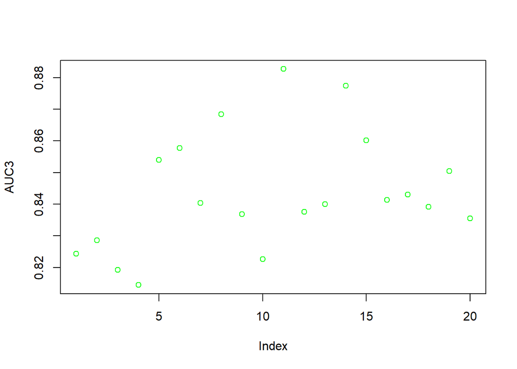

```r
plot(AUC3, col = "green")
```

```r
library(PASWR)
library(ROCR)
library(rpart)
# Data for rpart
remove(list = ls())

data(titanic3)
a <- c("survived","sex","age","pclass","sibsp","parch")
dd <- titanic3[, a]
dd$survived <- as.factor(dd$survived)
df <- dd #for rpart
dff <- df[complete.cases(df),] # for rf
AUC <- c()

maxnode=c(10, 50, 100, 250, 500, 750, 1000)
for (i in 1:length(maxnode)) {

model <- randomForest(survived~sex+age+pclass+sibsp+parch,
maxnodes = maxnode[i], data = dff)
phat <- model$votes[,2]

#AUC
pred_rocr1 <- prediction(phat, dff$survived)
auc_ROCR1 <- performance(pred_rocr1, measure = "auc")
AUC[i] <- auc_ROCR1@y.values[[1]]
print(c(maxnode[i],AUC[i]))
}
```

```
## [1] 10.0000000  0.8401914
## [1] 50.0000000  0.8469599
## [1] 100.0000000   0.8445479
## [1] 250.0000000   0.8453822
## [1] 500.0000000   0.8445442
## [1] 750.0000000   0.8459875
## [1] 1000.0000000    0.8436532
```

## 5. After 50 the AUC started to decrease from 0.8469599 to 0.8445479, 0.8453822, and 0.8445442. Therefore, I am going to write another script using mixmode between 10 to 90. Let’s see

```r
library(PASWR)
library(ROCR)
library(rpart)
# Data for rpart
remove(list = ls())

data(titanic3)
a <- c("survived","sex","age","pclass","sibsp","parch")
dd <- titanic3[, a]
dd$survived <- as.factor(dd$survived)
df <- dd #for rpart
dff <- df[complete.cases(df),] # for rf
AUC <- c()

maxnode= seq(10, 90,5)
for (i in 1:length(maxnode)) {

model <- randomForest(survived~sex+age+pclass+sibsp+parch,
maxnodes = maxnode[i], data = dff)
phat <- model$votes[,2]

#AUC
pred_rocr1 <- prediction(phat, dff$survived)
auc_ROCR1 <- performance(pred_rocr1, measure = "auc")
AUC[i] <- auc_ROCR1@y.values[[1]]
print(c(maxnode[i],AUC[i]))
}
```

```
## [1] 10.0000000  0.8411788
## [1] 15.0000000  0.8421625
## [1] 20.0000000  0.8457416
## [1] 25.0000000  0.8474555
## [1] 30.0000000  0.8462845
## [1] 35.000000  0.846678
## [1] 40.0000000  0.8475595
## [1] 45.0000000  0.8464775
## [1] 50.0000000  0.8470866
## [1] 55.0000000  0.8454654
## [1] 60.0000000  0.8447674
## [1] 65.0000000  0.8427603
## [1] 70.0000000  0.8442528
## [1] 75.000000  0.847045
## [1] 80.0000000  0.8422628
## [1] 85.0000000  0.8427924
## [1] 90.0000000  0.8436834
```

## 6. It seems the range is between 25 which is 0.8474555 and 50 which is 0.8470866, so I run another script by increasing the sequence by only 2.

```r
library(PASWR)
library(ROCR)
library(rpart)
# Data for rpart
remove(list = ls())

data(titanic3)
a <- c("survived","sex","age","pclass","sibsp","parch")
dd <- titanic3[, a]
dd$survived <- as.factor(dd$survived)
df <- dd #for rpart
dff <- df[complete.cases(df),] # for rf
AUC <- c()

maxnode= seq(25, 50,2)
for (i in 1:length(maxnode)) {

model <- randomForest(survived~sex+age+pclass+sibsp+parch,
maxnodes = maxnode[i], data = dff)
phat <- model$votes[,2]

#AUC
pred_rocr1 <- prediction(phat, dff$survived)
auc_ROCR1 <- performance(pred_rocr1, measure = "auc")
AUC[i] <- auc_ROCR1@y.values[[1]]
print(c(maxnode[i],AUC[i]))
}
```

```
## [1] 25.0000000  0.8461502
## [1] 27.0000000  0.8490445
## [1] 29.0000000  0.8513505
## [1] 31.0000000  0.8478925
## [1] 33.0000000  0.8502268
## [1] 35.0000000  0.8489121
## [1] 37.00000  0.84811
## [1] 39.0000000  0.8481043
## [1] 41.0000000  0.8492904
## [1] 43.0000000  0.8463602
## [1] 45.0000000  0.8478036
## [1] 47.0000000  0.8469542
## [1] 49.0000000  0.8475898
```